# Weather Modeling

```r
# Define key predictor variables for base XGB runs
baseXGBPreds <- c("locNamefct", "month", "hrfct",
                  "DewF", "modSLP", "Altimeter", "WindSpeed",
                  "predomDir", "minHeight", "ceilingHeight"
                  )

# Core multi-year cities
multiYearLocales <- c("Las Vegas, NV", "New Orleans, LA", "Chicago, IL", "San Diego, CA")

# Run the function shell
xgbInit <- xgbRunModel(filter(metarData, !is.na(TempF)),
                       depVar="TempF",
                       predVars=baseXGBPreds,
                       otherVars=c("source", "dtime"),
                       critFilter=list(locNamefct=multiYearLocales),
                       seed=2008011825,
                       nrounds=2000,
                       print_every_n=50
                       )
```

Functions can then be written to assess the quality of the predictions:

```
## # A tibble: 10 x 4
##    Feature          Gain  Cover Frequency
##    <chr>           <dbl>  <dbl>     <dbl>
##  1 locNamefct    0.241   0.0696    0.0496
##  2 month         0.123   0.0810    0.122
##  3 hrfct         0.0460  0.104     0.159
##  4 DewF          0.387   0.134     0.166
##  5 modSLP        0.0682  0.288     0.158
##  6 Altimeter     0.0724  0.197     0.0815
##  7 WindSpeed     0.00745 0.0446    0.100
##  8 predomDir     0.00468 0.0375    0.0778
##  9 minHeight     0.0168  0.0250    0.0505
## 10 ceilingHeight 0.0332  0.0202    0.0350
```

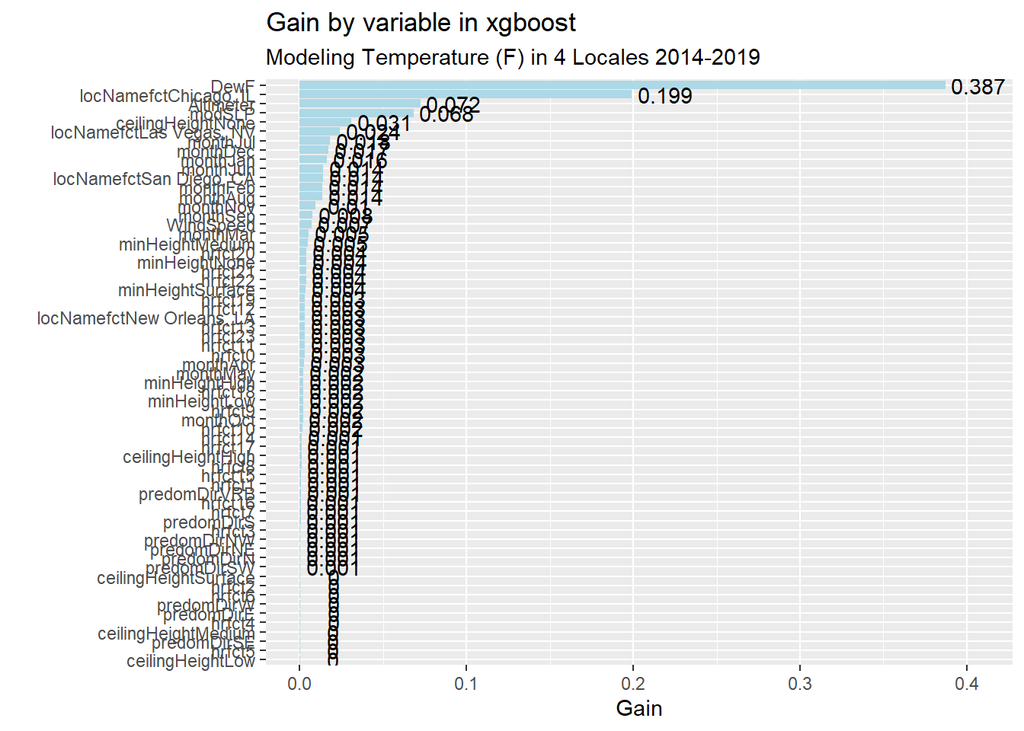

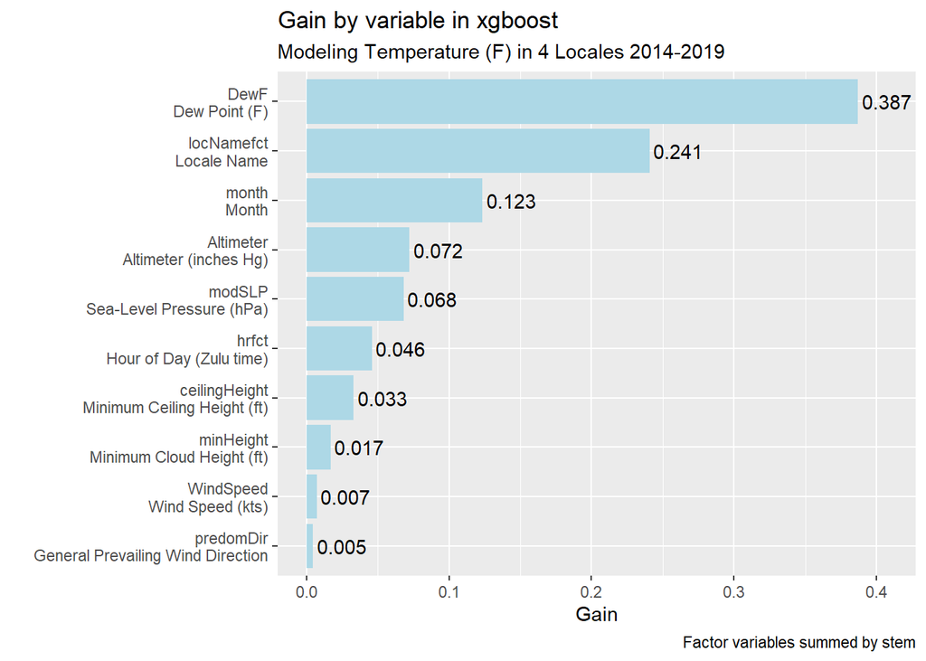

```r
# Create and plot importance for XGB model
plotXGBImportance <- function(mdl,
                              subList="xgbModel",
                              featureStems=NULL,
                              showMainPlot=TRUE,
                              showStemPlot=!is.null(featureStems),
                              stemMapper=NULL,
                              plotTitle="Gain by Variable for xgboost",
                              plotSubtitle=NULL
                              ) {

    # FUNCTION ARGUMENTS:
    # mdl: the xgb.Booster model file, or a list containing the xgb.Booster model file
    # subList: if mdl is a list, attempt to pull out item named in subList
    # featureStems: aggregate features starting with this vector of stems, and plot sum of gain
    #               (NULL means do not do this and just plot the gains "as is" )
    # showMainPlot: boolean, whether to create the full importance plot (just return importance data otherwise)
    # showStemPlot: boolean, whether to create the plot summed by stems
    # stemMapper: mapping file to convert stem variables to descriptive names (NULL means leave as-is)
    # plotTitle: title to be included on the importance plots
    # plotSubtitle: subtitle to be included on the importance plots (NULL means no subtitle)

    # Pull out the modeling data from the list if needed
    if (!("xgb.Booster" %in% class(mdl))) {
        mdl <- mdl[[subList]]
    }

    # Pull out the feature importances
    xgbImportance <- xgboost::xgb.importance(model=mdl)

    # Helper function to sum data to stem (called below if featureStems is not NULL)
    helperStemTotal <- function(pattern, baseData=xgbImportance) {
        baseData %>%
            filter(grepl(pattern=paste0("^", pattern), x=Feature)) %>%
            select_if(is.numeric) %>%
            colSums()
    }

    # Create sums by stem if requested
    if (!is.null(featureStems)) {
        stemTotals <- sapply(featureStems, FUN=function(x) { helperStemTotal(pattern=x) } ) %>%
            t() %>%
            as.data.frame() %>%
            rownames_to_column("Feature") %>%
            tibble::as_tibble()
        print(stemTotals)
    } else {
        stemTotals <- NULL
    }

    # Helper function to plot gain by Feature
    helperPlotGain <- function(df, title, subtitle, mapper=NULL, caption=NULL) {
        # Add descriptive name if mapper is passed
        if (!is.null(mapper)) df <- df %>% mutate(Feature=paste0(Feature, "\n", mapper[Feature]))
        p1 <- df %>%
            ggplot(aes(x=fct_reorder(Feature, Gain), y=Gain)) +
            geom_col(fill="lightblue") +
            geom_text(aes(y=Gain+0.02, label=round(Gain, 3))) +
            coord_flip() +
            labs(x="", title=title)
        if (!is.null(subtitle)) { p1 <- p1 + labs(subtitle=subtitle) }
        if (!is.null(caption)) { p1 <- p1 + labs(caption=caption) }
        print(p1)
    }

    # Create and display the plots if requested
    if (showMainPlot) helperPlotGain(xgbImportance, title=plotTitle, subtitle=plotSubtitle)
    if (showStemPlot) {
        helperPlotGain(stemTotals,
                       title=plotTitle,
                       subtitle=plotSubtitle,
                       mapper=stemMapper,
                       caption="Factor variables summed by stem"
                       )
    }

    # Return a list containing the raw data and the stemmed data (can be NULL)
    list(importanceData=xgbImportance, stemData=stemTotals)

}

# Find and plot importances
xgbInit_importance <- plotXGBImportance(xgbInit,
                                        featureStems=baseXGBPreds,
                                        stemMapper = varMapper,
                                        plotTitle="Gain by variable in xgboost",
                                        plotSubtitle="Modeling Temperature (F) in 4 Locales 2014-2019"
                                        )
```

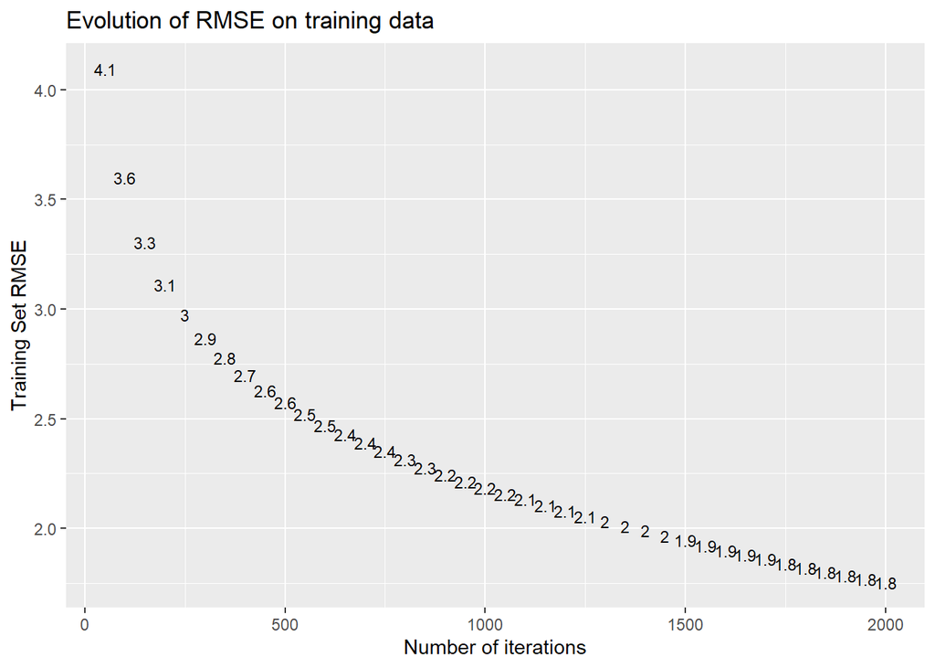

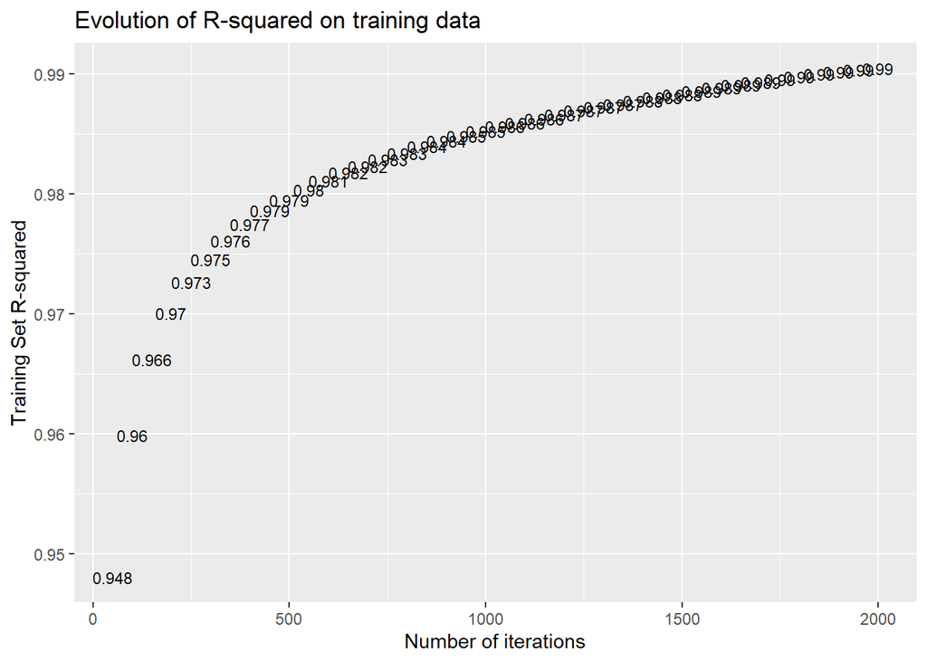

```r
# Function to create and plot RMSE and R-squared evolution of training data
plotXGBTrainEvolution <- function(mdl,
                                  fullSD,
                                  subList="xgbModel",
                                  plotRMSE=TRUE,
                                  plotR2=TRUE,
                                  plot_every=10
                                  ) {

    # FUNCTION ARGUMENTS:
    # mdl: the xgb.Booster model file, or a list containing the xgb.Booster model file
    # fullSD: the overall stansard deviation for the training variable
    #         if passed as numeric, use as-is
    #         if passed as character, try to extract sd of that variable from 'testData' in mdl
    # subList: if mdl is a list, attempt to pull out item named in subList
    # plotRMSE: boolean, whether to create the RMSE evolution plot
    # plotR2: boolean, whether to create the R2 evolution plot
    # plot_every: how often to plot the RMSE/R-squared data (e.g., 10 means print iter 10, 20, 30, etc.)

    # Create the full standard deviation from 'testData' if passed as character
    # Must be run before mdl is converted out of list format
    if (is.character(fullSD)) {
        fullSD <- mdl[["testData"]] %>% pull(fullSD) %>% sd()
    }

    # Pull out the modeling data from the list if needed
    if (!("xgb.Booster" %in% class(mdl))) {
        mdl <- mdl[[subList]]
    }

    # Extract the evaluation log and add an approximated R-squared
    rmseR2 <- mdl[["evaluation_log"]] %>%
        mutate(overall_rmse=fullSD, rsq=1-train_rmse**2/overall_rmse**2) %>%
        tibble::as_tibble()

    # Helper function to create requested plot(s)
    helperPlotEvolution <- function(df, yVar, rnd, desc, size=3, plot_every=1) {
        p1 <- df %>%
            filter((iter %% plot_every) == 0) %>%
            ggplot(aes_string(x="iter", y=yVar)) +
            geom_text(aes(label=round(get(yVar), rnd)), size=size) +
            labs(x="Number of iterations",
                 y=paste0("Training Set ", desc),
                 title=paste0("Evolution of ", desc, " on training data")
                 )
        print(p1)
    }

    # Create the RMSE and R-squared plots if requested
    if (plotRMSE) helperPlotEvolution(rmseR2, yVar="train_rmse", rnd=1, desc="RMSE", plot_every=plot_every)
    if (plotR2) helperPlotEvolution(rmseR2, yVar="rsq", rnd=3, desc="R-squared", plot_every=plot_every)

    # Return the full evolution data frame
    rmseR2

}

# Plot the evolution
xgbInitEvolution <- plotXGBTrainEvolution(xgbInit, fullSD="TempF", plot_every=50)
```

```
##
## OVERALL PREDICTIVE PERFORMANCE:
##
## # A tibble: 1 x 3
##   rmse_orig rmse_xgb   rsq
##       <dbl>    <dbl> <dbl>
## 1      18.0     2.98 0.972
##
##
##
## PREDICTIVE PERFORMANCE BY GROUP(S):
##
## # A tibble: 4 x 4
##   locNamefct      rmse_orig rmse_xgb   rsq
##   <fct>               <dbl>    <dbl> <dbl>
## 1 Chicago, IL         21.1      3.24 0.976
## 2 Las Vegas, NV       18.3      2.75 0.977
## 3 New Orleans, LA     13.3      3.03 0.948
## 4 San Diego, CA        7.37     2.89 0.846
##
## # A tibble: 12 x 4
##    month rmse_orig rmse_xgb   rsq
##    <fct>     <dbl>    <dbl> <dbl>
##  1 Jan        17.0     2.90 0.971
##  2 Feb        17.6     3.07 0.970
##  3 Mar        14.9     3.08 0.957
##  4 Apr        12.4     3.22 0.932
##  5 May        11.6     3.08 0.929
##  6 Jun        12.2     2.82 0.946
##  7 Jul        11.1     2.78 0.937
##  8 Aug        10.1     2.67 0.930
##  9 Sep        10.3     2.90 0.920
## 10 Oct        11.8     3.15 0.929
## 11 Nov        14.1     3.18 0.949
## 12 Dec        14.2     2.88 0.959
```

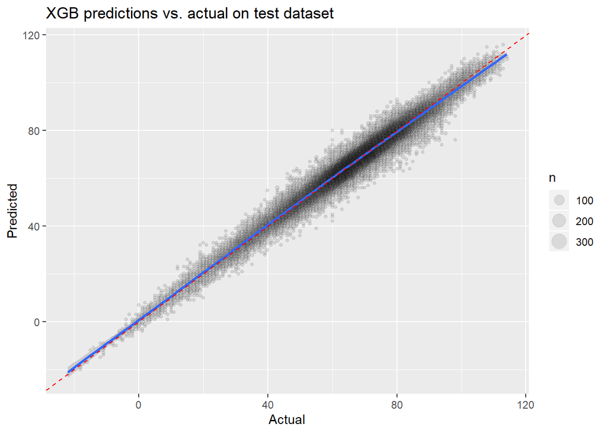

```r
# Function to report on, and plot, prediction caliber on testData
plotXGBTestData <- function(mdl,
                            depVar,
                            predVar="predicted",
                            subList="testData",
                            reportOverall=TRUE,
                            reportBy=NULL,
                            showPlot=TRUE
                            ) {

    # FUNCTION ARGUMENTS:
    # mdl: the test data file, or a list containing the test data file
    # depVar: the variable that was predicted
    # predVar: the variable containing the prediction for depVar
    # subList: if mdl is a list, attempt to pull out item named in subList
    # reportOverall: boolean, whether to report an overall RMSE/R2 on test data
    # reportBy: variable for sumarizing RMSE/R2 by (NULL means no RMSE/R2 by any grouping variables)
    # showPlot: boolean, whether to create/show the plot of predictions vs actuals

    # Pull out the modeling data from the list if needed
    if ("list" %in% class(mdl)) {
        mdl <- mdl[[subList]]
    }

    # Helper function to print RMSE and R2
    helperReportRMSER2 <- function(df, depVar, errVar) {
        df %>%
            summarize(rmse_orig=sd(get(depVar)),
                      rmse_xgb=mean((get(predVar)-get(depVar))**2)**0.5
                      ) %>%
            mutate(rsq=1-rmse_xgb**2/rmse_orig**2) %>%
            print()
        cat("\n")
    }

    # Report overall RMSE/R2 if requested
    if (reportOverall) {
        cat("\nOVERALL PREDICTIVE PERFORMANCE:\n\n")
        helperReportRMSER2(mdl, depVar=depVar, errVar=errVar)
        cat("\n")
    }

    # Report by grouping variables if any
    if (!is.null(reportBy)) {
        cat("\nPREDICTIVE PERFORMANCE BY GROUP(S):\n\n")
        sapply(reportBy, FUN=function(x) {
            mdl %>% group_by_at(x) %>% helperReportRMSER2(depVar=depVar, errVar=errVar)
        }
        )
        cat("\n")
    }

    # Show overall model performance using rounded temperature and predictions
    if (showPlot) {
        p1 <- mdl %>%
            mutate(rndPred=round(get(predVar))) %>%
            group_by_at(vars(all_of(c(depVar, "rndPred")))) %>%
            summarize(n=n()) %>%
            ggplot(aes_string(x=depVar, y="rndPred")) +
            geom_point(aes(size=n), alpha=0.1) +
            geom_smooth(aes(weight=n)) +
            geom_abline(lty=2, color="red") +
            labs(title="XGB predictions vs. actual on test dataset", y="Predicted", x="Actual")
        print(p1)
    }

}

# Assess performance on test data
plotXGBTestData(xgbInit, depVar="TempF", reportBy=c("locNamefct", "month"))
```

The XGB model appears to be over-fitting the training data, as reflected by the RMSE gap between the test data set and the training data set:

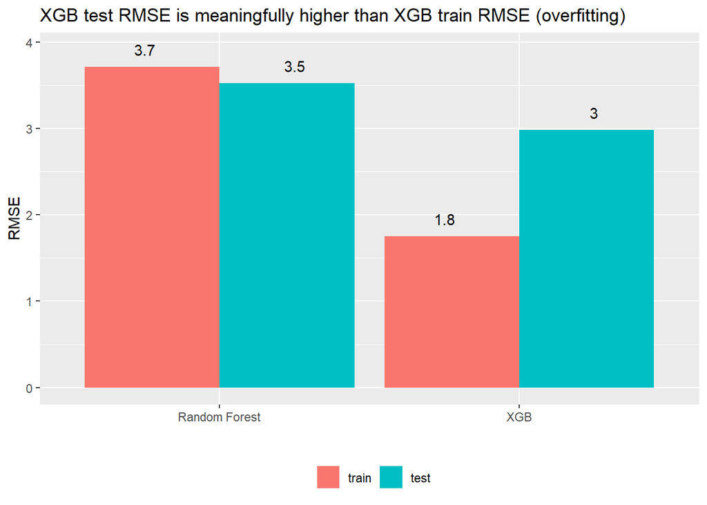

```r
# Get the random forest by locale RMSE reported by the training process
rfByLocaleRMSE <- sapply(lstFullData_002, FUN=function(x) { x[[1]][["rfModel"]][["mse"]] }) %>%
    as.data.frame() %>%
    tibble::as_tibble() %>%
    mutate(train_rmse=apply(., 1, FUN=mean)**0.5)

# Get the random forest RMSE reported by the test data
rfTestRMSE <- fullTestData_002 %>%
    summarize(rfTestrmse=mean(err**2)**0.5) %>%
    pull(rfTestrmse)

# Get the XGB RMSE reported by the training process
xgbInitRMSE <- xgbInit$xgbModel$evaluation_log

# Get the XGB RMSE reported by the test data
xgbTestRMSE <- xgbInit$testData %>%
    summarize(xgbTestrmse=mean(err**2)**0.5) %>%
    pull(xgbTestrmse)

# Plot differences in train/test RMSE
tibble::tibble(model=c("Random Forest", "XGB"),
               train=c(tail(rfByLocaleRMSE$train_rmse, 1), tail(xgbInitRMSE$train_rmse, 1)),
               test=c(rfTestRMSE, xgbTestRMSE)
               ) %>%
    pivot_longer(-model, names_to="type", values_to="RMSE") %>%
    mutate(type=factor(type, levels=c("train", "test"))) %>%
    ggplot(aes(x=model, y=RMSE, fill=type)) +
    geom_col(position="dodge") +
    geom_text(aes(y=RMSE+0.2, label=round(RMSE, 1)), position=position_dodge(width=1)) +
    labs(x="", title="XGB test RMSE is meaningfully higher than XGB train RMSE (overfitting)") +
    scale_fill_discrete("") +
    theme(legend.position="bottom")
```

So, the XGB model either needs to be tuned, or it needs to run for a much smaller number of iterations. The function xgb.cv allows for cross-validation during the training process, which means that a running count of train/test RMSE is kept by iteration. Suppose that this function is run:

```r
# Create the same training dataset as would have been passed to the previous XGB modeling
xgbInput_big4 <- metarData %>%
    filter(!is.na(TempF), locNamefct %in% multiYearLocales) %>%
    anti_join(xgbInit$testData %>% select(source, dtime)) %>%
    select_at(vars(all_of(c("TempF", baseXGBPreds, "source", "dtime")))) %>%
    mutate_if(is.factor, .funs=fct_drop)
# Step 1: Convert to sparse matrix format using one-hot encoding with no intercept
xgbTrain_big4 <- helperMakeSparse(xgbInput_big4, predVars=baseXGBPreds)

# Step 2: Create the target output variable as a vector
xgbTarget_big4 <- xgbInput_big4$TempF

# Step 3: Train the model using xgboost::xgb.cv, as regression
xgbInit_cv <- xgboost::xgb.cv(data=xgbTrain_big4,
                              label=xgbTarget_big4,
                              nrounds=2000,
                              nfold=5,
                              print_every_n=50,
                              objective="reg:squarederror"
                              )
```

The evolution of RMSE can then be plotted:

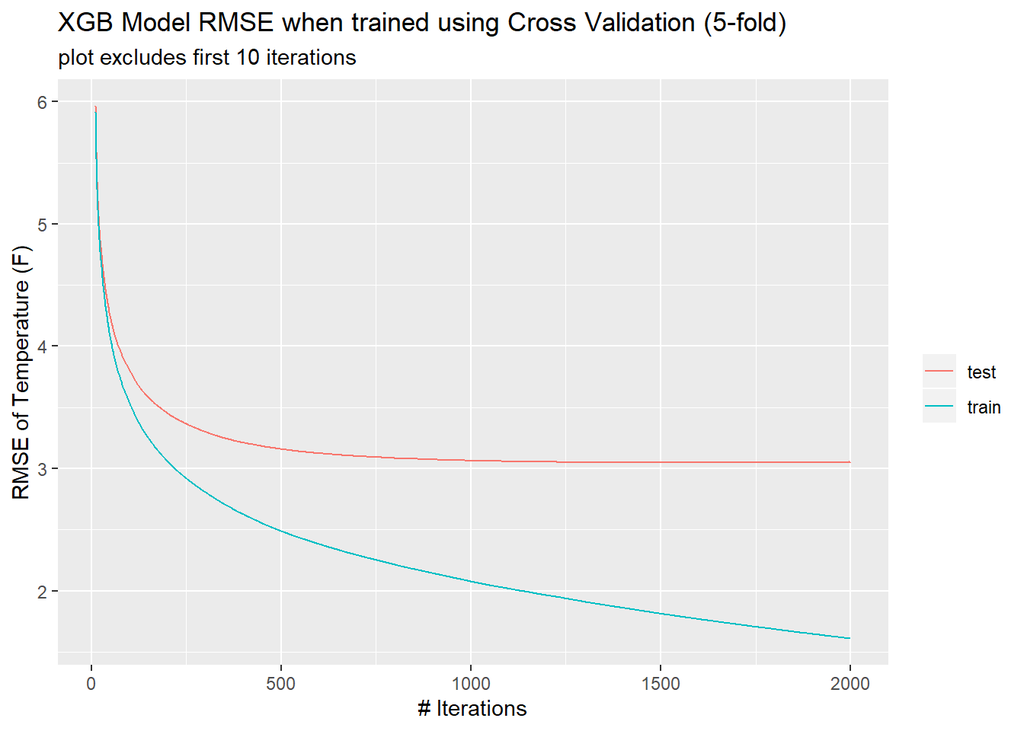

```r
xgbInit_cv$evaluation_log %>%
    select(iter, train=train_rmse_mean, test=test_rmse_mean) %>%
    pivot_longer(-iter, names_to="type", values_to="rmse") %>%
    filter(iter > 10) %>%
    ggplot(aes(x=iter, y=rmse, color=type, group=type)) +
    geom_line() +
    scale_color_discrete("") +
    labs(x="# Iterations",
         y="RMSE of Temperature (F)",
         title="XGB Model RMSE when trained using Cross Validation (5-fold)",
         subtitle="plot excludes first 10 iterations"
         )
```

There is a significant divergence between train RMSE and test RMSE, with test RMSE mostly being optimized already after 500-1000 iterations, while train RMSE continues to improve almost linearly even after 1000 iterations. Unlike random forests, which minimize variance through bootstrap resampling and variable shuffling at each split, the XGB model continues to tune on residuals in the same dataset even after it has learned every pattern that can be generalized to unseen data. Proper use of CV and early-stopping will be important.

Notably, XGB has achieved roughly 3.0 degrees RMSE with the test data while random forest achieved roughly 3.5 degrees with the test data. In part this is driven by the very fast optimization of XGB allowing for many more iterations than can be run in the same time for a random forest.

Potential next steps are to incorporate xgb.cv as an option in the training function, and to explore hyperparameters such as eta (learning rate) and maximum depth, and their impacts on the test set RMSE.

Function xgbRunModel has been updated to accept either xgboost::xgboost or xgboost::xgb.cv. This allows for running several versions of the hyperparameters through the CV process. For example:

```r
# Create hyperparameter space
hypGrid <- expand.grid(eta=c(0.1, 0.3, 0.6),
                       max_depth=c(3, 6, 10),
                       nrounds=500,
                       nfold=5
                       )

# Create containers for results
xgbSmall <- vector("list", nrow(hypGrid))

# Run xgb.cv once for each combination of hyper-parameters
for (rowNum in 1:nrow(hypGrid)) {

    # Extract the relevant hyperparameter data row
    params <- hypGrid[rowNum, ] %>% unlist()

    # Run the function for 5-fold CV for a few values of eta and max_depth
    xgbTemp <- xgbRunModel(filter(metarData, !is.na(TempF)),
                           depVar="TempF",
                           predVars=baseXGBPreds,
                           otherVars=c("source", "dtime"),
                           critFilter=list(locNamefct=multiYearLocales),
                           seed=2008041345,
                           nrounds=params["nrounds"],
                           eta=params["eta"],
                           max_depth=params["max_depth"],
                           print_every_n=50,
                           funcRun=xgboost::xgb.cv,
                           nfold=params["nfold"]
                           )

    xgbSmall[[ rowNum]] <- list(params=params, results=xgbTemp)

}
```

The test and train RMSE by iteration can be extracted and plotted by combination of parameters:

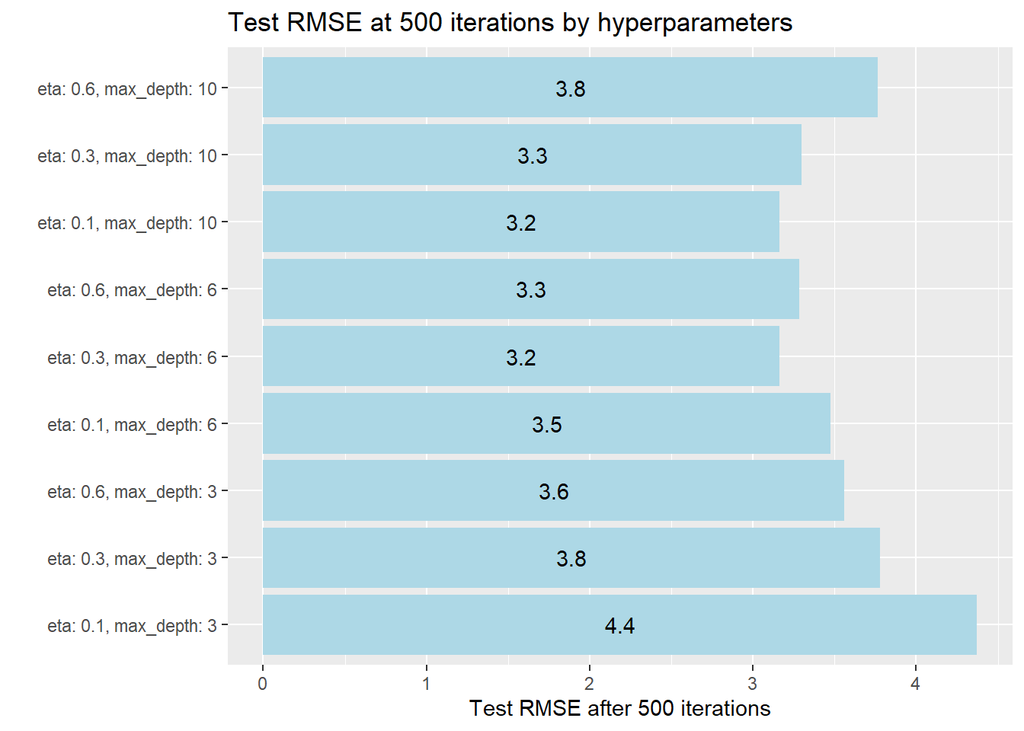

```r
# Extract the key parameters as a character vector
allParams <- sapply(xgbSmall, FUN=function(x) x[["params"]])
keyParamVec <- allParams %>%
    apply(2, FUN=function(x) paste0(names(x)[1], ": ", x[1], ", ", names(x)[2], ": ", x[2]))

# Extract RMSE and attach character vector
allRMSE <- map_dfr(xgbSmall,
                   .f=function(x) x[["results"]][["xgbModel"]]$evaluation_log,
                   .id="source"
                   ) %>%
    mutate(desc=factor(keyParamVec[as.numeric(source)], levels=keyParamVec)) %>%
    tibble::as_tibble()

# Get the minimum test RMSE
minTestRMSE <- allRMSE %>%
    select(test_rmse_mean) %>%
    min()

# Create plot for final test RMSE
allRMSE %>%
    select(desc, iter, train=train_rmse_mean, test=test_rmse_mean) %>%
    filter(iter==max(iter)) %>%
    ggplot(aes(x=desc, y=test)) +
    geom_col(fill="lightblue") +
    geom_text(aes(y=test/2, label=round(test, 1))) +
    labs(x="", y="Test RMSE after 500 iterations", title="Test RMSE at 500 iterations by hyperparameters") +
    coord_flip()
```

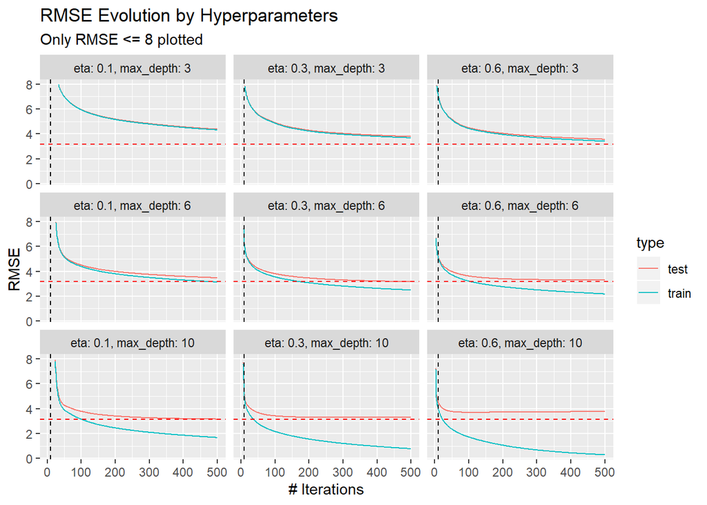

```r
# Create plot for RMSE evolution
allRMSE %>%
    select(desc, iter, train=train_rmse_mean, test=test_rmse_mean) %>%
    pivot_longer(-c(desc, iter), names_to="type", values_to="RMSE") %>%
    filter(RMSE <= 8) %>%
    ggplot(aes(x=iter, y=RMSE, group=type, color=type)) +
    geom_line() +
    labs(x="# Iterations", title="RMSE Evolution by Hyperparameters", subtitle="Only RMSE <= 8 plotted") +
    geom_hline(aes(yintercept=minTestRMSE), color="red", lty=2) +
    geom_vline(aes(xintercept=10), lty=2) +
    facet_wrap(~desc)
```

As expected, increasing eta and max_depth have a tendency to induce over-fitting while also driving to the optimal RMSE quicker. A trade-off. The default eta=0.3 and max_depth=6 appear to be close to the minimum RMSE at 500 observations with a rather modest delta between test/train RMSE. The high over-fit model (eta 0.6 and max_depth 10) appears to have converged with a high test RMSE. The slowest model (eta 0.1, max_depth 3) appears to still have significant room to learn even after 500 observations.

The top performing models at 500 iterations appear to be blends of parameters that average out to “moderate-high” learning ability (low eta=0.1 with high max_depth=10, medium eta=0.3 with medium max_depth=6, medium eta=0.3 with high max_depth=10, high eta=0.6 with medium max_depth=6).

Suppose the slowest model is run for 2500 iterations to check on convergence:

```r
# Define key predictor variables for base XGB runs
baseXGBPreds <- c("locNamefct", "month", "hrfct",
                  "DewF", "modSLP", "Altimeter", "WindSpeed",
                  "predomDir", "minHeight", "ceilingHeight"
                  )

# Core multi-year cities
multiYearLocales <- c("Las Vegas, NV", "New Orleans, LA", "Chicago, IL", "San Diego, CA")

# Run the function shell
xgbSlow <- xgbRunModel(filter(metarData, !is.na(TempF)),
                       depVar="TempF",
                       predVars=baseXGBPreds,
                       otherVars=c("source", "dtime"),
                       critFilter=list(locNamefct=multiYearLocales),
                       seed=2008041432,
                       nrounds=2500,
                       print_every_n=50,
                       eta=0.1,
                       max_depth=3
                       )
```

The evalutaion functions can then be run:

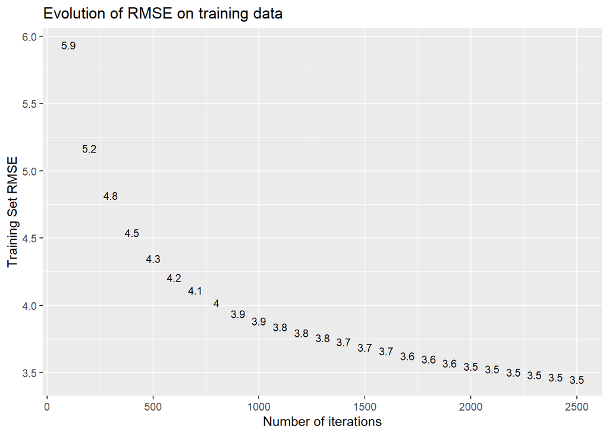

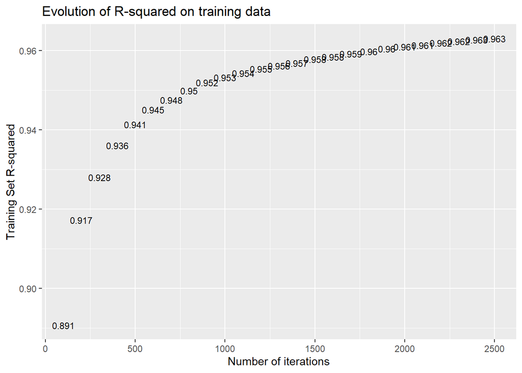

```r
# Plot the evolution
xgbSlowEvolution <- plotXGBTrainEvolution(xgbSlow, fullSD="TempF", plot_every=100)
```

```
##
## OVERALL PREDICTIVE PERFORMANCE:
##
## # A tibble: 1 x 3
##   rmse_orig rmse_xgb   rsq
##       <dbl>    <dbl> <dbl>
## 1      18.0     3.54 0.961
##
##
##
## PREDICTIVE PERFORMANCE BY GROUP(S):
##
## # A tibble: 4 x 4
##   locNamefct      rmse_orig rmse_xgb   rsq
##   <fct>               <dbl>    <dbl> <dbl>
## 1 Chicago, IL         21.1      4.01 0.964
## 2 Las Vegas, NV       18.2      3.29 0.967
## 3 New Orleans, LA     13.4      3.47 0.933
## 4 San Diego, CA        7.35     3.32 0.796
##
## # A tibble: 12 x 4
##    month rmse_orig rmse_xgb   rsq
##    <fct>     <dbl>    <dbl> <dbl>
##  1 Jan        17.2     3.42 0.960
##  2 Feb        17.7     3.73 0.956
##  3 Mar        14.8     3.70 0.937
##  4 Apr        12.5     4.00 0.898
##  5 May        11.4     3.78 0.890
##  6 Jun        12.0     3.33 0.923
##  7 Jul        11.1     3.06 0.924
##  8 Aug        10.3     2.88 0.922
##  9 Sep        10.2     3.38 0.890
## 10 Oct        11.6     3.72 0.896
## 11 Nov        14.0     3.86 0.924
## 12 Dec        14.2     3.42 0.942
```

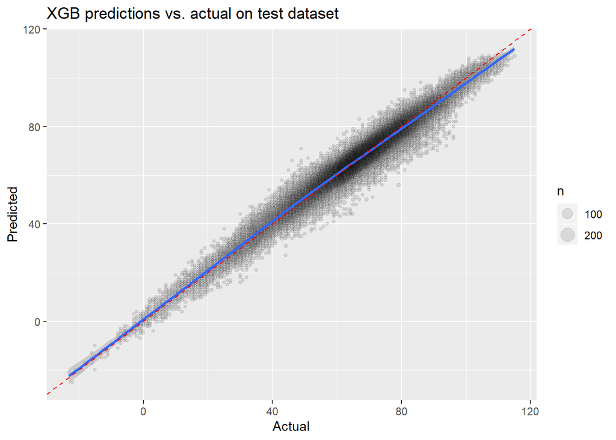

```r
# Assess performance on test data
plotXGBTestData(xgbSlow, depVar="TempF", reportBy=c("locNamefct", "month"))
```

Even at 2500 iterations, the model has almost no over-fitting (train RMSE 3.5, test RMSE 3.5). However, the model appears to be converging at several tenths of a degree higher test RMSE than some of the other models achieve in as little as 500 iterations.